# clickR: Limpieza semiautomática de datos

David Hervás Marín

2025-11-05

## Ejemplo sencillo: mtcars_messy

Para poder realizar el ejemplo, primero nos aseguramos de tener instalado y cargado el paquete `clickR`. También usaremos el paquete `DT` para las tablas de este documento markdown.

```r
if(!require(clickR)){
  install.packages("clickR")
  library(clickR)
}
if(!require(DT)){
  install.packages("DT")
  library(DT)
}
```

Ahora podemos ver los datos, que vienen con el propio paquete

```r
datatable(mtcars_messy, options=list(pageLength = 32))
```

|  | Mpg | cyl | disp | hp | drat | wt | qsec | vs | am | n Gears | carb | date | maker |
| --- | --- | --- | --- | --- | --- | --- | --- | --- | --- | --- | --- | --- | --- |
| Mazda RX4 | 21 | 6 | 160 | 110 | 3.9 | 2.62 | 16.46 | 0 | 1 | 4 | 4 | 1973-03-23 | mazda |
| Mazda RX4 Wag | 21 | 6 | 160 | 110 | 3.9 | 2.875 | 17.02 | 0 | 1 | 4 | 4 | 1974-10-30 | Mazda |
| Datsun 710 | 22,8 | 4 | 108 | 93 | 3.85 | 2.32 | 18.61 | 1 | 1 | 4 | 1 | 1973-12-23 | Datsun |
| Hornet 4 Drive | 21.,4 | 6 | 258 | 110 | 3.08 | 3.215 | 19.44 | 1 | 0 | 3 | 1 | 1974-06-16 | ornet |
| Hornet Sportabout | 18.7 | 8 | 360 | 175 | 3.15 | 3.44 | 17.02 | 0 | 0 | 3 | 2 | 1974-07-08 | Hornet |
| Valiant | 18.1 | 6 | 225 | 105 | 2.76 | 3.46 | 20.22 | 1 | 0 | 3 | 1 | 1974-03-02 | Valiant |
| Duster 360 | 14.3 mpg | 8 | 360 | 245 |  | 3.57 | 15.84 | 0 | 0 | 3 | 4 | 26/08/1974 | Duster |
| Merc 240D | 24.4 | 4 | 146.7 | 62 | 3.69 | 3.19 | 20 | 1 | 0 | 4 | 2 | 1974-05-27 | Merc |
| Merc 230 | 22.8 | 4 | 140.8 | 95 | 3.92 | 3.15 | 22.9 | 1 | 0 | 4 | 2 | 1973-06-09 | Merc |
| Merc 280 | 19.2 | 6 | 167.6 | 123 | 3.92 | 3.44 | 18.3 | 1 | 0 | 4 | 4 | 1973-12-05 | Merc |

[output cut: 22 more lines]

### Arreglar nombres de variables

Lo primero que podemos hacer es poner unos nombres de variable más manejables. La función `nice_names()` pone todos los nombres en minúsculas, sustituye espacios en blanco por “_” o por “” según su ubicación y quita caracteres extraños.

```r
mtcars_messy <- nice_names(mtcars_messy)
```

Las funciones de `clickR` que realizan cambios en los datos registras estos cambios en un log, de modo que tenemos una trazabilidad total de los cambios exactos realizados por cada función. Podemos revisar el log mediante la función `track_changes()`

```r
track_changes(mtcars_messy)
```

```
##  variable observation original     new        fun
##       mpg     varname      Mpg     mpg nice_names
##        hp     varname      hp       hp nice_names
##   n_gears     varname  n Gears n_gears nice_names
```

La salida de la función nos muestra que se ha cambiado el nombre de tres variables, de las cuales podemos ver tanto el nombre original como el corregido, así como la función que ha realizado dicho cambio.

### Descriptivo de los datos

Como paso siguiente vamos a hacer un descriptivo general de los datos para ver cómo de mal están las cosas. En estos datos de ejemplo podemos ver la tabla entera y buscar los errores observación a observación, pero en datos reales esto no sería factible.

```r
descriptive(mtcars_messy)
```

```
## Data frame with 32 observations and 13 variables.
##
## Numeric variables (7)
##          Min  1st Q. Median 3rd Q.   Max    Mean      SD Kurtosis Skewness Modes NAs                   Distribution
## cyl      4.0   4.000   6.00    8.0   8.0   6.188   1.786   -1.762   -0.175    2    0 [#############:##############]
## disp    71.1 120.825 196.30  326.0 472.0 230.722 123.939   -1.207    0.382    2    0 |---[####:########]----------|
## hp      52.0  96.500 123.00  180.0 335.0 146.688  68.563   -0.136    0.726    1    0 |----[#:#####]---------------|
## qsec    14.5  16.892  17.71   18.9  22.9  17.849   1.787    0.335    0.369    1    0 |-------[##:###]-------------|
## am       0.0   0.000   0.00    1.0   1.0   0.406   0.499   -1.925    0.364    2    0 :############################]
## n_gears  3.0   3.000   4.00    4.0   5.0   3.688   0.738   -1.070    0.529    3    0 [#############:--------------|
## carb     1.0   2.000   2.00    4.0   8.0   2.812   1.615    1.257    1.051    2    0 |---:#######]----------------|
##
## Categorical variables (6)
##       N. Classes              Classes       Mode Prop. mode  Anti-mode Prop. Anti-mode NAs
## mpg           28 10.4/15.2/21/30.4/19       10.4      0.062       19.2           0.031   0
## drat          22 3.07/3.92/2.76/3.08/       3.07      0.094          -           0.031   0
## wt            29 3.44/3.57/1.513/1.61       3.44      0.094      1.513           0.031   0
## vs             4           0/1/?/NULL          0        0.5          ?           0.031   0
## date          32 06/25/1974/12/22/73/ 06/25/1974      0.031 06/25/1974           0.031   0
## maker         26 Mrc/Ft/AMC/Cdllc/Cmr       Merc      0.188        AMC           0.031   0
```

En la salida del descriptivo vemos muchos problemas. Las variables `mpg`, `drat` y `wt` deberían ser numéricas, pero salen como categóricas. La variable `am` es categórica, pero sale como numérica. La variable `date` no se ha reconocido como fecha. Además, en las categorías de algunas variables vemos valores extraños como `?` o `NULL`.

### Arreglar missing values

Aquí nos referimos a asegurarnos que todo lo que debería ser reconocido como un missing value lo es.

```r
mtcars_messy <- fix_NA(mtcars_messy)
```

```
## Your parallel configuration is plansequential
```

Como antes, vamos a revisar los cambios con `track_changes()`. La función tienen un argumento que permite establecer filtros lógicos para ver únicamente los cambios que cumplen alguna condición.

```r
track_changes(mtcars_messy, fun == "fix_NA")
```

```
##  variable        observation original  new    fun
##      drat         Duster 360          <NA> fix_NA
##      drat        Honda Civic        - <NA> fix_NA
##        vs Cadillac Fleetwood        ? <NA> fix_NA
##        vs      Porsche 914-2     NULL <NA> fix_NA
```

Vemos que hemos cambiado 4 valores que obviamente eran missings mal codificados por `NA`.

### Arreglar fechas en múltiples formatos

Vamos a echar un vistazo a la variable `date`

```r
mtcars_messy$date
```

```
##  [1] "1973-03-23"    "1974-10-30"    "1973-12-23"    "1974-06-16"    "1974-07-08"    "1974-03-02"    "26/08/1974"    "1974-05-27"    "1973-06-09"    "1973-12-05"    "3rd July 1974" "06/25/1974"
## [13] "1973-06-04"    "1973-01-04"    "1973-03-21"    "1973-12-17"    "1973-01-11"    "1974-07-27"    "1974-02-18"    "19/06/74"      "1973-03-15"    "1973-12-21"    "1974-11-28"    "1974-05-03"
## [25] "1974-03-30"    "1973-09-16"    "1973-07-26"    "14 /08-1974"   "1974-03-07"    "1974-05-16"    "1973, 03, 03"  "12/22/73"
```

¡Es una maravilla! Tenemos 8 formatos distintos de fecha en la misma columna. Podemos arreglarlo con la función `fix_dates()`

```r
mtcars_messy <- fix_dates(mtcars_messy)
```

```
## Your parallel configuration is plansequential
```

```
## 0 new missing values generated
```

```
## 0 variables excluded following max.NA criterion
```

```
## 0 variables excluded following min.obs criterion
```

```r
track_changes(mtcars_messy, fun == "fix_dates")
```

```
##  variable    observation      original        new       fun
##      date            all     character       Date fix_dates
##      date     Duster 360    26/08/1974 1974-08-26 fix_dates
##      date      Merc 280C 3rd July 1974 1974-07-03 fix_dates
##      date     Merc 450SE    06/25/1974 1974-06-25 fix_dates
##      date Toyota Corolla      19/06/74 1974-06-19 fix_dates
##      date   Lotus Europa   14 /08-1974 1974-08-14 fix_dates
##      date  Maserati Bora  1973, 03, 03 1973-03-03 fix_dates
##      date     Volvo 142E      12/22/73 1973-12-22 fix_dates
```

Si revisamos el log de cambios vemos que todos los cambios son, aparentemente, correctos.

### Arreglar variables numéricas con errores

En el breve análisis exploratorio inicial hemos visto varios problemas en las variables numéricas. Decimales con coma y con punto, observaciones con las unidades, notación científica no reconocida… Podemos arreglar todos estos problemas con la función `fix_numerics()`

```r
mtcars_messy <- fix_numerics(mtcars_messy)
```

```
## Your parallel configuration is plansequential
```

```
## 0 new missing values generated
```

```
## 0 variables excluded following max.NA criterion
```

```r
track_changes(mtcars_messy, fun == "fix_numerics")
```

```
##  variable         observation  original     new          fun
##       mpg                 all character numeric fix_numerics
##      drat                 all character numeric fix_numerics
##        wt                 all character numeric fix_numerics
##       mpg          Datsun 710      22,8    22.8 fix_numerics
##       mpg      Hornet 4 Drive     21.,4    21.4 fix_numerics
##       mpg          Duster 360  14.3 mpg    14.3 fix_numerics
##       mpg            Merc 280      19.2    19.2 fix_numerics
##       mpg           Merc 280C   1.78e01    17.8 fix_numerics
##        wt Lincoln Continental     5,424   5.424 fix_numerics
##        wt   Chrysler Imperial     5,345   5.345 fix_numerics
```

¡Todo arreglado!

### Arreglar variables categóricas

Dentro del tratamiento de las variables categóricas tenemos dos funciones distintas. La primera es `fix_factors()`, que detecta columnas `character` que deberían ser factores y las recodifica, además de estandarizar los niveles del factor eliminando espacios en blanco, mayúsculas/minúsculas, etc. Por otra parte, tenemos la función `fix_levels()` que sirve para corregir problemas más severos de estandarización de niveles de los factores cuando hay muchas discrepancias, erratas, etc. Vamos a ver un ejemplo de funcionamiento de las dos.

```r
mtcars_messy <- fix_factors(mtcars_messy)
track_changes(mtcars_messy, fun == "fix_factors")
```

```
##  variable observation  original    new         fun
##       cyl         all   numeric factor fix_factors
##        vs         all character factor fix_factors
##        am         all   numeric factor fix_factors
##   n_gears         all   numeric factor fix_factors
```

La función ha detectado que las variables `cyl`, `vs`, `am` y `n_gears` tienen muy pocas categorías, por lo que son sospechosas de ser factores y las ha recodificado como tal.

Ahora probaremos `fix_levels()`. Esta función, a diferencia del resto de funciones presentadas, no corrige todos los errores del data.frame a la vez, sino que requiere que se le especifique la variable que hay que corregir. En este caso vamos a centrarnos en la variable `maker`, que tiene unas cuantas erratas que están haciendo que un mismo fabricante parezca distinto: toyota/toyotta, merc/merck, ornet/hornet.

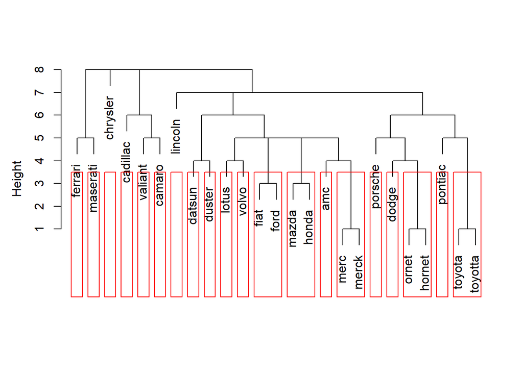

```
## Groups of levels:
##
## $`1`
## [1] "mazda" "honda"
##
## $`2`
## [1] "datsun"
##
## $`3`
## [1] "ornet"  "hornet"
##
## $`4`
## [1] "valiant"
##
## $`5`
## [1] "duster"
##
## $`6`
## [1] "merc"  "merck"
##
## $`7`
## [1] "cadillac"
##
## $`8`
## [1] "lincoln"
##
## $`9`
## [1] "chrysler"
##
## $`10`
## [1] "fiat" "ford"
##
## $`11`
## [1] "toyota"  "toyotta"
##
## $`12`
## [1] "dodge"
##
## $`13`
## [1] "amc"
##
## $`14`
## [1] "camaro"
##
## $`15`
## [1] "pontiac"
##
## $`16`
## [1] "porsche"
##
## $`17`
## [1] "lotus"
##
## $`18`
## [1] "ferrari"
##
## $`19`
## [1] "maserati"
##
## $`20`
## [1] "volvo"
```

```r
#Primero hacemos una tentativa del número de niveles distintos que tiene la variable.
fix_levels(mtcars_messy, "maker", plot = TRUE, k = 20)  #Vemos que algunas categorías agrupadas no deberían estarlo
```

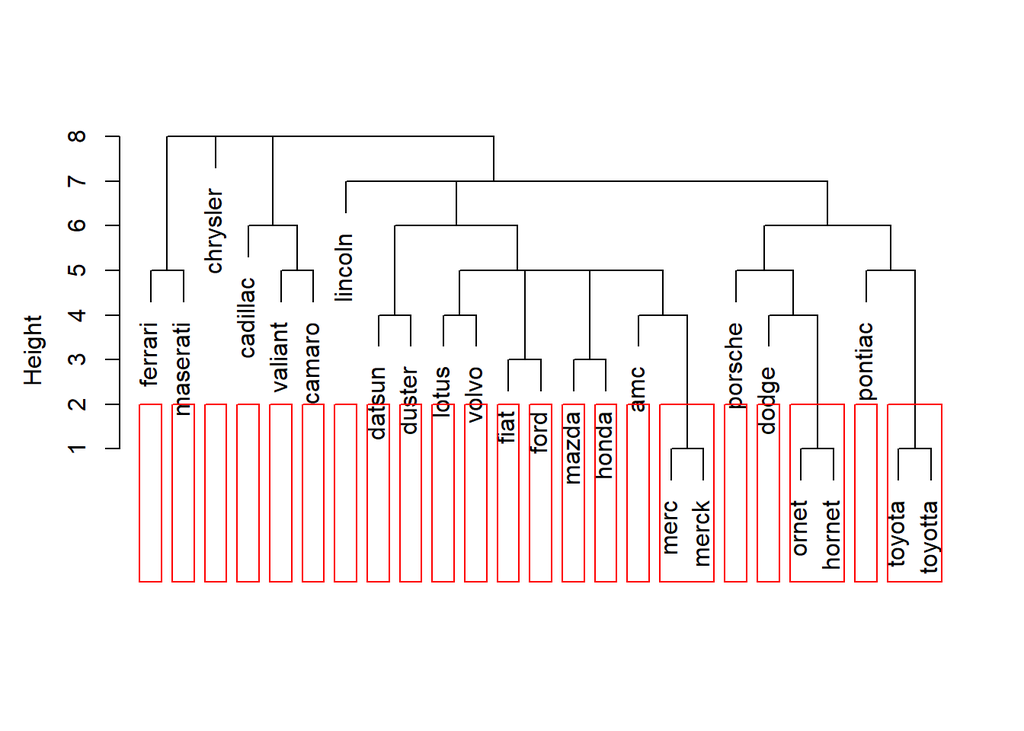

```
## Groups of levels:
##
## $`1`
## [1] "mazda"
##
## $`2`
## [1] "datsun"
##
## $`3`
## [1] "ornet"  "hornet"
##
## $`4`
## [1] "valiant"
##
## $`5`
## [1] "duster"
##
## $`6`
## [1] "merc"  "merck"
##
## $`7`
## [1] "cadillac"
##
## $`8`
## [1] "lincoln"
##
## $`9`
## [1] "chrysler"
##
## $`10`
## [1] "fiat"
##
## $`11`
## [1] "honda"
##
## $`12`
## [1] "toyota"  "toyotta"
##
## $`13`
## [1] "dodge"
```

[output cut: 12 more lines]

```
##
## $`18`
## [1] "lotus"
##
## $`19`
## [1] "ford"
##
## $`20`
## [1] "ferrari"
##
## $`21`
## [1] "maserati"
##
## $`22`
## [1] "volvo"
```

```r
fix_levels(mtcars_messy, "maker", plot = TRUE, k = 22)  #Ahora sí es correcto
```

Una vez que tenemos claro el valor de `k`, asignamos el resultado de la función.

```r
mtcars_messy <- fix_levels(mtcars_messy, "maker", k = 22, levels = "auto")
track_changes(mtcars_messy, fun == "fix_levels")
```

```
##  variable         observation original      new        fun
##     maker       Mazda RX4 Wag    Mazda    mazda fix_levels
##     maker          Datsun 710   Datsun   datsun fix_levels
##     maker      Hornet 4 Drive    ornet   hornet fix_levels
##     maker   Hornet Sportabout   Hornet   hornet fix_levels
##     maker             Valiant  Valiant  valiant fix_levels
##     maker          Duster 360   Duster   duster fix_levels
##     maker           Merc 240D     Merc     merc fix_levels
##     maker            Merc 230     Merc     merc fix_levels
##     maker            Merc 280     Merc     merc fix_levels
##     maker           Merc 280C     Merc     merc fix_levels
##     maker          Merc 450SE    merck     merc fix_levels
##     maker          Merc 450SL     Merc     merc fix_levels
##     maker         Merc 450SLC     Merc     merc fix_levels
##     maker  Cadillac Fleetwood Cadillac cadillac fix_levels
##     maker Lincoln Continental  Lincoln  lincoln fix_levels
##     maker   Chrysler Imperial Chrysler chrysler fix_levels
##     maker            Fiat 128     Fiat     fiat fix_levels
##     maker         Honda Civic    Honda    honda fix_levels
##     maker      Toyota Corolla   Toyota   toyota fix_levels
##     maker       Toyota Corona  toyotta   toyota fix_levels
##     maker    Dodge Challenger    Dodge    dodge fix_levels
##     maker         AMC Javelin      AMC      amc fix_levels
##     maker          Camaro Z28   Camaro   camaro fix_levels
##     maker    Pontiac Firebird  Pontiac  pontiac fix_levels
##     maker           Fiat X1-9     Fiat     fiat fix_levels
##     maker       Porsche 914-2  Porsche  porsche fix_levels
##     maker        Lotus Europa    Lotus    lotus fix_levels
##     maker      Ford Pantera L     Ford     ford fix_levels
##     maker        Ferrari Dino  Ferrari  ferrari fix_levels
##     maker       Maserati Bora Maserati maserati fix_levels
##     maker          Volvo 142E    Volvo    volvo fix_levels
```

### Restablecer algún cambio

Independientemente del orden en el que se han realizado los cambios, estos pueden restablecerse mediante la función `restore_changes()` que admite como entrada el listado de cambios producido por `track_changes`. Como ejemplo, vamos a restablecer los cambios realizados por la función `fix_numerics()` sobre la variable `wt`.

```r
restore <- track_changes(mtcars_messy, fun == "fix_numerics" & variable == "wt")
```

```
##  variable         observation  original     new          fun
##        wt                 all character numeric fix_numerics
##        wt Lincoln Continental     5,424   5.424 fix_numerics
##        wt   Chrysler Imperial     5,345   5.345 fix_numerics
```

```r
mtcars_messy_r <- restore_changes(restore)
```

```r
mtcars_messy[c("Lincoln Continental", "Chrysler Imperial"), "wt"]
```

```
## [1] 5.424 5.345
```

Vamos a hacer un descriptivo final para ver cómo han quedado los datos

```r
descriptive(mtcars_messy)
```

```
## Data frame with 32 observations and 13 variables.
##
## Numeric variables (7)
##         Min  1st Q.  Median 3rd Q.     Max    Mean      SD Kurtosis Skewness Modes NAs                   Distribution
## mpg  10.400  15.425  19.200  22.80  33.900  20.091   6.027   -0.373    0.611    1    0 |-----[####:###]-------------|
## disp 71.100 120.825 196.300 326.00 472.000 230.722 123.939   -1.207    0.382    2    0 |---[####:########]----------|
## hp   52.000  96.500 123.000 180.00 335.000 146.688  68.563   -0.136    0.726    1    0 |----[#:#####]---------------|
## drat  2.760   3.080   3.695   3.92   4.430   3.565   0.488   -1.409   -0.103    2    2 |-----[#########:###]--------|
## wt    1.513   2.581   3.325   3.61   5.424   3.217   0.978   -0.023    0.423    1    0 |-------[####:##]------------|
## qsec 14.500  16.892  17.710  18.90  22.900  17.849   1.787    0.335    0.369    1    0 |-------[##:###]-------------|
## carb  1.000   2.000   2.000   4.00   8.000   2.812   1.615    1.257    1.051    2    0 |---:#######]----------------|
##
## Categorical variables (5)
##         N. Classes              Classes Mode Prop. mode Anti-mode Prop. Anti-mode NAs
## cyl              3                8/4/6    8      0.438         6           0.219   0
## vs               2                  0/1    0      0.533         1           0.467   2
## am               2                  0/1    0      0.594         1           0.406   0
## n_gears          3                3/4/5    3      0.469         5           0.156   0
## maker           22 merc/mzd/hrnt/ft/tyt merc      0.219    datsun           0.031   0
##
## Date variables (1)
##             Min     1st Q.     Median     3rd Q.        Max       Mean      SD Kurtosis Skewness NAs                   Distribution
## date 1973-01-04 1973-07-14 1974-02-24 1974-06-20 1974-11-28 1974-01-07 204.707   -1.168   -0.389   0 |-------[########:####]------|
```

Por último, podemos revisar el log completo con todos los cambios realizados.

```r
datatable(track_changes(mtcars_messy), options=list(pageLength = 20), rownames=FALSE)
```

```
##  variable         observation      original        new          fun
##       mpg             varname           Mpg        mpg   nice_names
##        hp             varname           hp          hp   nice_names
##   n_gears             varname       n Gears    n_gears   nice_names
##      drat          Duster 360                     <NA>       fix_NA
##      drat         Honda Civic             -       <NA>       fix_NA
##        vs  Cadillac Fleetwood             ?       <NA>       fix_NA
##        vs       Porsche 914-2          NULL       <NA>       fix_NA
##      date                 all     character       Date    fix_dates
##      date          Duster 360    26/08/1974 1974-08-26    fix_dates
##      date           Merc 280C 3rd July 1974 1974-07-03    fix_dates
##      date          Merc 450SE    06/25/1974 1974-06-25    fix_dates
##      date      Toyota Corolla      19/06/74 1974-06-19    fix_dates
##      date        Lotus Europa   14 /08-1974 1974-08-14    fix_dates
##      date       Maserati Bora  1973, 03, 03 1973-03-03    fix_dates
##      date          Volvo 142E      12/22/73 1973-12-22    fix_dates
##       mpg                 all     character    numeric fix_numerics
##      drat                 all     character    numeric fix_numerics
##        wt                 all     character    numeric fix_numerics
##       mpg          Datsun 710          22,8       22.8 fix_numerics
##       mpg      Hornet 4 Drive         21.,4       21.4 fix_numerics
##       mpg          Duster 360      14.3 mpg       14.3 fix_numerics
##       mpg            Merc 280          19.2       19.2 fix_numerics
##       mpg           Merc 280C       1.78e01       17.8 fix_numerics
##        wt Lincoln Continental         5,424      5.424 fix_numerics
##        wt   Chrysler Imperial         5,345      5.345 fix_numerics
##       cyl                 all       numeric     factor  fix_factors
##        vs                 all     character     factor  fix_factors
##        am                 all       numeric     factor  fix_factors
##   n_gears                 all       numeric     factor  fix_factors
##     maker       Mazda RX4 Wag         Mazda      mazda   fix_levels
##     maker          Datsun 710        Datsun     datsun   fix_levels
##     maker      Hornet 4 Drive         ornet     hornet   fix_levels
##     maker   Hornet Sportabout        Hornet     hornet   fix_levels
##     maker             Valiant       Valiant    valiant   fix_levels
##     maker          Duster 360        Duster     duster   fix_levels
##     maker           Merc 240D          Merc       merc   fix_levels
##     maker            Merc 230          Merc       merc   fix_levels
##     maker            Merc 280          Merc       merc   fix_levels
##     maker           Merc 280C          Merc       merc   fix_levels
##     maker          Merc 450SE         merck       merc   fix_levels
##     maker          Merc 450SL          Merc       merc   fix_levels
##     maker         Merc 450SLC          Merc       merc   fix_levels
##     maker  Cadillac Fleetwood      Cadillac   cadillac   fix_levels
##     maker Lincoln Continental       Lincoln    lincoln   fix_levels
##     maker   Chrysler Imperial      Chrysler   chrysler   fix_levels
##     maker            Fiat 128          Fiat       fiat   fix_levels
##     maker         Honda Civic         Honda      honda   fix_levels
##     maker      Toyota Corolla        Toyota     toyota   fix_levels
##     maker       Toyota Corona       toyotta     toyota   fix_levels
##     maker    Dodge Challenger         Dodge      dodge   fix_levels
##     maker         AMC Javelin           AMC        amc   fix_levels
##     maker          Camaro Z28        Camaro     camaro   fix_levels
##     maker    Pontiac Firebird       Pontiac    pontiac   fix_levels
##     maker           Fiat X1-9          Fiat       fiat   fix_levels
##     maker       Porsche 914-2       Porsche    porsche   fix_levels
##     maker        Lotus Europa         Lotus      lotus   fix_levels
##     maker      Ford Pantera L          Ford       ford   fix_levels
##     maker        Ferrari Dino       Ferrari    ferrari   fix_levels
##     maker       Maserati Bora      Maserati   maserati   fix_levels
##     maker          Volvo 142E         Volvo      volvo   fix_levels
```

| variable | observation | original | new | fun |
| --- | --- | --- | --- | --- |
| mpg | varname | Mpg | mpg | nice_names |
| hp | varname | hp | hp | nice_names |
| n_gears | varname | n Gears | n_gears | nice_names |
| drat | Duster 360 |  |  | fix_NA |
| drat | Honda Civic | - |  | fix_NA |
| vs | Cadillac Fleetwood | ? |  | fix_NA |
| vs | Porsche 914-2 | NULL |  | fix_NA |
| date | all | character | Date | fix_dates |
| date | Duster 360 | 26/08/1974 | 1974-08-26 | fix_dates |
| date | Merc 280C | 3rd July 1974 | 1974-07-03 | fix_dates |

[output cut: 50 more lines]

## Función buscar y reemplazar

Antes de seguir con el tutorial de limpieza abordando un ejemplo más complejo, me gustaría comentar una función del paquete `clickR` que le gustará mucho a los usuarios de Excel: `f_replace()`. Como en el Excel, busca una determinada cadena de caracteres o numérica en el data.frame y reemplaza por otra cadena especificada.

```r
f_replace(iris, "setosa", "reticulata")
```

```
##     Sepal.Length Sepal.Width Petal.Length Petal.Width    Species
## 1            5.1         3.5          1.4         0.2 reticulata
## 2            4.9         3.0          1.4         0.2 reticulata
## 3            4.7         3.2          1.3         0.2 reticulata
## 4            4.6         3.1          1.5         0.2 reticulata
## 5            5.0         3.6          1.4         0.2 reticulata
## 6            5.4         3.9          1.7         0.4 reticulata
## 7            4.6         3.4          1.4         0.3 reticulata
## 8            5.0         3.4          1.5         0.2 reticulata
## 9            4.4         2.9          1.4         0.2 reticulata
## 10           4.9         3.1          1.5         0.1 reticulata
## 11           5.4         3.7          1.5         0.2 reticulata
## 12           4.8         3.4          1.6         0.2 reticulata
## 13           4.8         3.0          1.4         0.1 reticulata
## 14           4.3         3.0          1.1         0.1 reticulata
```

[output cut: 136 more lines]

```r
f_replace(iris, 0.2, 0.4)
```

```
##     Sepal.Length Sepal.Width Petal.Length Petal.Width    Species
## 1            5.1         3.5          1.4         0.4     setosa
## 2            4.9         3.0          1.4         0.4     setosa
## 3            4.7         3.2          1.3         0.4     setosa
## 4            4.6         3.1          1.5         0.4     setosa
## 5            5.0         3.6          1.4         0.4     setosa
## 6            5.4         3.9          1.7         0.4     setosa
## 7            4.6         3.4          1.4         0.3     setosa
## 8            5.0         3.4          1.5         0.4     setosa
## 9            4.4         2.9          1.4         0.4     setosa
## 10           4.9         3.1          1.5         0.1     setosa
## 11           5.4         3.7          1.5         0.4     setosa
## 12           4.8         3.4          1.6         0.4     setosa
## 13           4.8         3.0          1.4         0.1     setosa
## 14           4.3         3.0          1.1         0.1     setosa
```

[output cut: 136 more lines]

Y también con búsquedas parciales

```r
iris_mod <- f_replace(iris, "t", "d", complete = FALSE)
```

Obviamente, los cambios quedan registrados en su correspondiente log

```r
track_changes(iris_mod)
```

```
##  variable observation original    new       fun
##   Species           1   setosa sedosa f_replace
##   Species           2   setosa sedosa f_replace
##   Species           3   setosa sedosa f_replace
##   Species           4   setosa sedosa f_replace
##   Species           5   setosa sedosa f_replace
##   Species           6   setosa sedosa f_replace
##   Species           7   setosa sedosa f_replace
##   Species           8   setosa sedosa f_replace
##   Species           9   setosa sedosa f_replace
##   Species          10   setosa sedosa f_replace
##   Species          11   setosa sedosa f_replace
##   Species          12   setosa sedosa f_replace
##   Species          13   setosa sedosa f_replace
##   Species          14   setosa sedosa f_replace
##   Species          15   setosa sedosa f_replace
##   Species          16   setosa sedosa f_replace
##   Species          17   setosa sedosa f_replace
##   Species          18   setosa sedosa f_replace
##   Species          19   setosa sedosa f_replace
##   Species          20   setosa sedosa f_replace
##   Species          21   setosa sedosa f_replace
##   Species          22   setosa sedosa f_replace
##   Species          23   setosa sedosa f_replace
##   Species          24   setosa sedosa f_replace
##   Species          25   setosa sedosa f_replace
##   Species          26   setosa sedosa f_replace
##   Species          27   setosa sedosa f_replace
##   Species          28   setosa sedosa f_replace
##   Species          29   setosa sedosa f_replace
##   Species          30   setosa sedosa f_replace
##   Species          31   setosa sedosa f_replace
##   Species          32   setosa sedosa f_replace
##   Species          33   setosa sedosa f_replace
##   Species          34   setosa sedosa f_replace
##   Species          35   setosa sedosa f_replace
##   Species          36   setosa sedosa f_replace
##   Species          37   setosa sedosa f_replace
##   Species          38   setosa sedosa f_replace
##   Species          39   setosa sedosa f_replace
##   Species          40   setosa sedosa f_replace
##   Species          41   setosa sedosa f_replace
##   Species          42   setosa sedosa f_replace
##   Species          43   setosa sedosa f_replace
##   Species          44   setosa sedosa f_replace
##   Species          45   setosa sedosa f_replace
##   Species          46   setosa sedosa f_replace
##   Species          47   setosa sedosa f_replace
##   Species          48   setosa sedosa f_replace
##   Species          49   setosa sedosa f_replace
##   Species          50   setosa sedosa f_replace
```

## Ejemplo más complejo: `messy_IMDB_dataset.csv`

Ahora vamos con unos datos más complejos para que probéis. Aquí necesitaréis investigar sobre alguna otra función del paquete como `fix_concat()`, `remove_empty()` o `manual_fix()`.

### Carga de datos

```r
datos_raw <- read.csv2("messy_IMDB_dataset.csv", encoding="latin1")  #¡Cuidado con las tildes!
peek(datos_raw)
```

```
## Data frame with  101  rows (showing  12  of  12  variables)
##
##       IMBD.title.ID Original.titlÊ                                Release.year Genrë.                    Duration  Country     Content.Rating Director             X       Income        Votes
## 1     tt0111161     The Shawshank Redemption                      1995-02-10   Drama                     142       USA         R              Frank Darabont       <NA>    $ 28815245    2.278.845
## 2     tt0068646     The Godfather                                 09 21 1972   Crime, Drama              175       USA         R              Francis Ford Coppola <NA>    $ 246120974   1.572.674
## 3     tt0468569     The Dark Knight                                23 -07-2008 Action, Crime, Drama      152       US          PG-13          Christopher Nolan    <NA>    $ 1005455211  2.241.615
## 4     tt0071562     The Godfather: Part II                        1975-09-25   Crime, Drama              220       USA         R              Francis Ford Coppola <NA>    $ 4o8,035,783 1.098.714
## 5     tt0110912     Pulp Fiction                                  1994-10-28   Crime, Drama                        USA         R              Quentin Tarantino    <NA>    $ 222831817   1.780.147
## 6     tt0167260     The Lord of the Rings: The Return of the King 22 Feb 04    Action, Adventure, Drama  201       New Zealand PG-13          Peter Jackson        <NA>    $ 1142271098  1.604.280
## 7     tt0108052     Schindler's List                              1994-03-11   Biography, Drama, History Nan       USA         R              Steven Spielberg     <NA>    $ 322287794   1.183.248
## 8     tt0050083     12 Angry Men                                  1957-09-04   Crime, Drama              96        USA         Not Rated      Sidney Lumet         <NA>    $ 576         668.473
## 9     tt1375666     Inception                                     2010-09-24   Action, Adventure, Sci-Fi 148       USA         PG-13          Christopher Nolan    <NA>    $ 869784991   2.002.816
## 10    tt0137523     Fight Club                                    10-29-99     Drama                     Inf       UK          R              David Fincher        <NA>    $ 101218804   1.807.440
##
## class character     character                                     character    character                 character character   character      character            logical character     character
## range (101)         (101)                                         (100)        (60)                      (73)      (19)        (9)            (65)                 ()      (101)         (101)
##
##
##       Score
## 1     9.3
## 2     9.2
## 3     9.
## 4     9,.0
## 5     8,9f
## 6     08.9
## 7     8.9
## 8     8.9
## 9     8..8
## 10    8.8
##
## class character
## range (29)
##
##
```